# 4_MLP

## The Multi-Layer Perceptron

```python
import matplotlib.pyplot as plt
import numpy as np
import pandas
```

- Perceptron is a linear model
- Why?
- Inherently simple - two solutions.
  - Transform the features to make the problem linearly separable
  - Make the network more complex
- The **multi-layer perceptron** builds on the second idea
- Learning with the perceptron occurs in the weights
- To make a more complex network, add more weights
- Two ways to do so
  - Add some backward connections - so neurons connect to inputs again
  - Add more neurons
- The first approach leads to **recurrent networks**
- The second approach leads to MLP
- It will allow us to add more "layers" of nuerons between the input nodes and the outputs

#### Going Forward

- Going *forward* means working out the outputs for given inputs
- This is the *recall* phase we discussed last time
- This is the same in the MLP as the Perceptron
- Only we do it twice now - layer-by-layer
- The activations of one layer of nodes are the inputs to the next

#### Going Backwards: Back-Propagation of Error

- Computing the errors is the same
- What to do with them - how to update the weights - is more difficult
- This is called **back-propagation of error**
- We do so through **gradient descent**
- We know we need to update the weights, but which ones? Inputs $\rightarrow$ hidden layer or hidden layer $\rightarrow$ outputs?
- Recall that our error function in the Perceptron was $E=t-y$
- For the MLP we will use the familiar sum of squares error $E(t,y)=\frac{1}{2}\sum_{k=1}^n(t_k-y_k)^2$

#### Activation Function

- We also need to revisit our activation function
- For the Perceptron, we used a binary activation function
- This is not differentiable
- For the MLP, we will use a *sigmoid* function
- You have seen an exmaple in the logistic function with the now-familiar S-shape $$g(h)=\frac{1}{1+e^{-\beta h}}$$

where $\beta > 0$

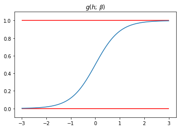

```python
fig, ax = plt.subplots()
g_func = lambda h, beta : 1/(1 + np.exp(-beta*h))
x = np.linspace(-3, 3, 100)

ax.plot(x, g_func(x, 2))
ax.hlines([0, 1], -3, 3, color="r")
ax.set_ylim(-.1, 1.1);
ax.set_title(r"$g(h;\, \beta)$");
```

#### Back-Propagation

- We feed our inputs forward through the network, which tells us which nodes are firing
- We compute the errors
- We need to compute the gradient of the errors with respect to the weights
- This allows us to update the weights in the "downhill" direction
  - Do this for the nodes connected to the output layer
  - Work backwards until we get back to the inputs again
- Two problems
  - We don't know the inputs to the output neurons
  - We don't know the targets for the hidden neurons (for multiple hidden layers - don't know the inputs or the outputs...)
- We can use the chain-rule from calculus to get around this

#### MLP Algorithm Overview

- An input vector is put into the input nodes
- Inputs are fed *forward* through the network
  - Inputs and first-layer weights $v$ determine wither the hidden nodes fire via $g(\cdot)$
  - Outputs of these nodes and the second-layer weights are used to decide if the output neurons fire
- Sum-of-squares error is computed
- Error is fed backwards through the network
  - Second-layer weights are updated (using $\delta_0$)
  - First-layer weights are updated (using $\delta_h$)

#### MLP Algorithm

- Initialization of weights
- **Training** (Repeat)
  - For each input vector

    **Forwards phase**
    - Compute the activation of each neuron $j$ in the hidden layer(s) using

    $$h_j=\sum_ix_iv_{ij}$$ $$a_j=g(h_j)=\frac{1}{1+e^{-\beta h_j}}$$
    - Work through network until you get the output layers

    $$h_k=\sum_j{a_jw_{jk}}$$ $$y_k=g(h_k)=\frac{1}{1+e^{-\beta h_k}}$$

    **Backwards phase**
    - compute the error at the output using

      $$\delta_{ok}=(t_k-y_k)y_k(1-y_k)$$
    - compute the error in the hidden layer(s) using

      $$\delta_{hj}=a_j(1-a_j)\sum_k w_{jk}\delta_{ok}$$
    - update the output layer weights using

      $$w_{jk}\leftarrow w_{jk} + \eta \delta_{ok}a_j$$
    - update the hidden layer weights using

      $$v_{ij}\leftarrow v_{ij}+\eta \delta_{hj}x_i$$

    Randomize the order of the input vectors so that you don't train in exactly the same order each iteration
- **Recall**
  - Use the Forwards Phase